# Text Operation - Advanced String Methods

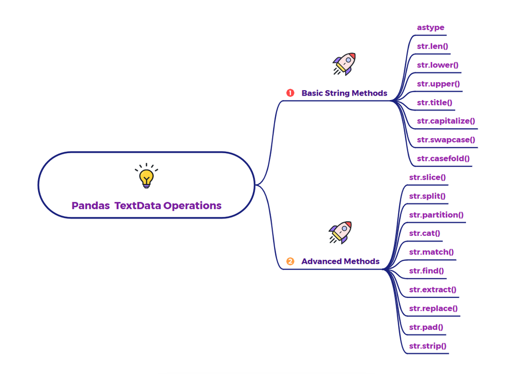

# Notebook Walkthrough -

- Advanced String Methods
- Advanced String Methods - Slice, Split, and Partition
- Advanced String Methods - Concatenations and Match
- Advanced String Methods - Find, Extract, and Replace
- Advanced String Methods - Leading and Trailing Characters

# 1. Advanced String Methods -

1. |df['column_name'].str.slice()| It is a way of selecting a subset of characters from a string column.|
2. |df['column_name'].str.slice_replace()| It enables us to replace a positional slice of a string with another value.|
3. |df['column_name'].str.split()| It splits a string column into multiple columns based on a separator..|
4. |df['column_name'].str.partition()| It splits the string at the first occurrence of the separator.|
5. |df['column_name'].str.cat()| It helps in concatenating strings.|
6. |df['column_name'].str.endswith()| Checks if each string value in the column ends with the mentioned string.|
7. |df['column_name'].str.contains()| Checks if each string value in the column match , can occur at any position within the string.|
8. |df['column_name'].str.match()| Checks if each string value in the column match , must begin at the string's first character.|
9. |df['column_name'].str.fullmatch()| Checks if each string value in the column match , the entire string must match the pattern.|
10. |df['column_name'].str.find()| It is used to search for a substring within each element of a DataFrame column and return the starting index of its first occurrence.|
11. |df['column_name'].str.findall()| It extracts all occurrences of the substring pattern so that the substring repetition count can be derived from the output..|
12. |df['column_name'].str.extract()| It is used to extract particular regex patterns that we want to extract from string values.|
13. |df['column_name'].str.extractall()| It is used to extract all particular regex patterns that we want to extract from string values.|
14. |df['column_name'].str.replace()| It is used to replacing each occurrence of a string or regex pattern.|
15. |df['column_name'].str.pad()| It is used for adding extra characters to the beginning or end of a string to make it up to a certain length.|
16. |df['column_name'].str.rjust()| Pads left side of strings with an arbitrary character. Equivalent to setting side='left' in pad().|
17. |df['column_name'].str.ljust()| Pads right side of strings with an arbitrary character. Equivalent to setting side='right' in pad().|
18. |df['column_name'].str.center()| Pads both sides of strings with an arbitrary character. Equivalent to setting side='both' in pad().|
19. |df['column_name'].str.zfill()| Pads left side of strings by prepending a 0 character. Equivalent to setting side='left' and fillchar='0' in pad(). |
20. |df['column_name'].str.strip()| It strips whitespaces (including newlines) or a set of specified characters from each string from the left and right sides.|
21. |df['column_name'].str.rstrip()| It is used if we only want to remove characters from the trailing side.|
22. |df['column_name'].str.removeprefix()| It is used if we’re dealing with string values that have a specific prefix.|
23. |df['column_name'].str.removesuffix()| It is used if we’re dealing with string values that have a specific suffix.|
24. |df['column_name'].str.wrap()| It is used to ensure that the text is wrapped across multiple lines to fit within the available width of the output display.|

# 2. Advanced String Methods - Slice, Split, and Partition

### A. Create sample dataset

```python
import pandas as pd

data = {
    "customer_id": ["264-42-4576", "763-23-7634", "763-55-7634"],
    "title": ['Mr', 'Ms', 'Dr'],
    "first_name": ['Raj', 'Neha', 'Ajay'],
    "last_name": ['martin', 'james', 'jones'],
    "ip_address": ['82.48.155.48/13', '95.48.177.48/18', '82.48.134.48/5'],
    "email": ['rmartin@james.edu', 'njames@gmail.com', 'ajones@yahoo.com'],

}
df = pd.DataFrame(data)
df
```

|  | customer_id | title | first_name | last_name | ip_address | email |
| --- | --- | --- | --- | --- | --- | --- |
| 0 | 264-42-4576 | Mr | Raj | martin | 82.48.155.48/13 | rmartin@james.edu |
| 1 | 763-23-7634 | Ms | Neha | james | 95.48.177.48/18 | njames@gmail.com |
| 2 | 763-55-7634 | Dr | Ajay | jones | 82.48.134.48/5 | ajones@yahoo.com |

### B. Advanced String Method - slice()

string slicing refers to the operation of extracting a substring (a portion) from a larger string. It works by specifying a range of indices, similar to how you might select a segment from a list or array. You define a starting index (inclusive) and an ending index (exclusive), and the slice will include all characters from the start up to, but not including, the end. This allows for precise selection of characters from any position within the string.

```python
# Method 1 - Index brackets for slicing

df['slicing_with_index_brackets'] = df['customer_id'].str[0:3]

# Method 2 - slice() method
df['slicing_with_slice_method'] = df['customer_id'].str.slice(start=0, stop=3)

# View output
df[['customer_id', 'slicing_with_index_brackets', 'slicing_with_slice_method']]
```

|  | customer_id | slicing_with_index_brackets | slicing_with_slice_method |
| --- | --- | --- | --- |
| 0 | 264-42-4576 | 264 | 264 |
| 1 | 763-23-7634 | 763 | 763 |
| 2 | 763-55-7634 | 763 | 763 |

```python
# Method 3 - Index brackets for slicing (with steps)

df['slicing_with_index_brackets'] = df['customer_id'].str[::2]

# Method 4 - slice() method (with steps)
df['slicing_with_slice_method'] = df['customer_id'].str.slice(start=0, step=2)

# View output
df[['customer_id', 'slicing_with_index_brackets', 'slicing_with_slice_method']]
```

|  | customer_id | slicing_with_index_brackets | slicing_with_slice_method |
| --- | --- | --- | --- |
| 0 | 264-42-4576 | 244-56 | 244-56 |
| 1 | 763-23-7634 | 732-64 | 732-64 |
| 2 | 763-55-7634 | 735-64 | 735-64 |

```python
# Slicing with replacement at index char positions 4 and 5

df['slice_replace'] = df['customer_id'].str.slice_replace(start=4,
                                                          stop=6,
                                                          repl='XX')
# View output
df[['customer_id', 'slice_replace']]
```

|  | customer_id | slice_replace |
| --- | --- | --- |
| 0 | 264-42-4576 | 264-XX-4576 |
| 1 | 763-23-7634 | 763-XX-7634 |
| 2 | 763-55-7634 | 763-XX-7634 |

### C. Advanced String Method - split()

String split() is a fundamental method used to break a single string into a list of smaller substrings. It performs this division based on occurrences of a specified delimiter (a character or sequence of characters). If no delimiter is provided, it defaults to splitting by any whitespace and discards empty strings. This function is extensively used in text processing to tokenize sentences into words, parse data separated by commas or other characters, or divide larger text blocks into smaller, manageable units.

```python
import pandas as pd

data = {
    "customer_id": ["264-42-4576", "763-23-7634", "763-55-7634"],
    "title": ['Mr', 'Ms', 'Dr'],
    "first_name": ['Raj', 'Neha', 'Ajay'],
    "last_name": ['martin', 'james', 'jones'],
    "ip_address": ['82.48.155.48/13', '95.48.177.48/18', '82.48.134.48/5'],
    "email": ['rmartin@james.edu', 'njames@gmail.com', 'ajones@yahoo.com'],

}
df = pd.DataFrame(data)
df
```

|  | customer_id | title | first_name | last_name | ip_address | email |
| --- | --- | --- | --- | --- | --- | --- |
| 0 | 264-42-4576 | Mr | Raj | martin | 82.48.155.48/13 | rmartin@james.edu |
| 1 | 763-23-7634 | Ms | Neha | james | 95.48.177.48/18 | njames@gmail.com |
| 2 | 763-55-7634 | Dr | Ajay | jones | 82.48.134.48/5 | ajones@yahoo.com |

```python
# 1. Splitting values with '-' as separator (aka delimiter)

output = df['customer_id'].str.split(pat='-')

print(output)

# Obtain first element (index 0) of each split list
output = df['customer_id'].str.split(pat='-').str.get(0)

print(output)
```

```
0    [264, 42, 4576]
1    [763, 23, 7634]
2    [763, 55, 7634]
Name: customer_id, dtype: object
0    264
1    763
2    763
Name: customer_id, dtype: object
```

```python
# 2. Splitting and expand values

output_df = df['customer_id'].str.split(pat='-', expand=True)

print(output_df)
print(type(output_df))

# Splitting and expand values, and limiting splits to just 1

output_df = df['customer_id'].str.split(pat='-', expand=True, n=1)

print(output_df)
```

```
     0   1     2
0  264  42  4576
1  763  23  7634
2  763  55  7634
<class 'pandas.core.frame.DataFrame'>
     0        1
0  264  42-4576
1  763  23-7634
2  763  55-7634
```

```python
# 3. Define regex for period, 3 digits, and a period

regex_pat = "\.\d{3}\."

# Splitting and expand values
output_df = df['ip_address'].str.split(pat=regex_pat,
                                       expand=True,
                                       regex=True)

# Concatenate original column to show split effect
output_df_2 = pd.concat([df[['ip_address']], output_df], axis=1)

print(output_df_2)
```

```
        ip_address      0      1
0  82.48.155.48/13  82.48  48/13
1  95.48.177.48/18  95.48  48/18
2   82.48.134.48/5  82.48   48/5
```

```python
# 4. Normal split

split_output = df['customer_id'].str.split(pat='-', expand=True, n=1)
print('Output of split()')
print(split_output)

print('=' * 25)

# Reverse split
rsplit_output = df['customer_id'].str.rsplit(pat='-', expand=True, n=1)
print('Output of rsplit()')
print(rsplit_output)
```

```
Output of split()
     0        1
0  264  42-4576
1  763  23-7634
2  763  55-7634
=========================
Output of rsplit()
        0     1
0  264-42  4576
1  763-23  7634
2  763-55  7634
```

### D. Advanced String Method - partition()

In string manipulation, the partition() method is used to split a string into three parts based on the first occurrence of a specified separator. It returns a tuple containing three elements: the portion of the string before the separator, the separator itself, and the portion of the string after the separator. If the separator is not found in the string, partition() returns a tuple containing the original string and two empty strings. This method is particularly useful for extracting specific segments of a string when you know a unique delimiter separates them.

```python
import pandas as pd

data = {
    "customer_id": ["264-42-4576", "763-23-7634", "763-55-7634"],
    "title": ['Mr', 'Ms', 'Dr'],
    "first_name": ['Raj', 'Neha', 'Ajay'],
    "last_name": ['martin', 'james', 'jones'],
    "ip_address": ['82.48.155.48/13', '95.48.177.48/18', '82.48.134.48/5'],
    "email": ['rmartin@james.edu', 'njames@gmail.com', 'ajones@yahoo.com'],

}
df = pd.DataFrame(data)
df
```

|  | customer_id | title | first_name | last_name | ip_address | email |
| --- | --- | --- | --- | --- | --- | --- |
| 0 | 264-42-4576 | Mr | Raj | martin | 82.48.155.48/13 | rmartin@james.edu |
| 1 | 763-23-7634 | Ms | Neha | james | 95.48.177.48/18 | njames@gmail.com |
| 2 | 763-55-7634 | Dr | Ajay | jones | 82.48.134.48/5 | ajones@yahoo.com |

```python
# 1. Partition at @ separator
output = df['email'].str.partition(sep='@')

output
```

|  | 0 | 1 | 2 |
| --- | --- | --- | --- |
| 0 | rmartin | @ | james.edu |
| 1 | njames | @ | gmail.com |
| 2 | ajones | @ | yahoo.com |

```python
# 2. Partition operation where separator is not found
output = df['email'].str.partition(sep='!')

output
```

|  | 0 | 1 | 2 |
| --- | --- | --- | --- |
| 0 | rmartin@james.edu |  |  |
| 1 | njames@gmail.com |  |  |
| 2 | ajones@yahoo.com |  |  |

```python
# 3. Normal partition

partition_output = df['customer_id'].str.partition(sep='-')
print('Output of partition()')
partition_output
```

```
Output of partition()
```

|  | 0 | 1 | 2 |
| --- | --- | --- | --- |
| 0 | 264 | - | 42-4576 |
| 1 | 763 | - | 23-7634 |
| 2 | 763 | - | 55-7634 |

```python
# 4. Reverse partition

rpartition_output = df['customer_id'].str.rpartition(sep='-')
print('Output of rpartition()')
rpartition_output
```

```
Output of rpartition()
```

|  | 0 | 1 | 2 |
| --- | --- | --- | --- |
| 0 | 264-42 | - | 4576 |
| 1 | 763-23 | - | 7634 |
| 2 | 763-55 | - | 7634 |

# 3. Advanced String Methods - Concatenations and Match

### A. Create sample dataset

```python
data = {
    "customer_id": ["264-42-4576", "763-23-7634", "763-55-7634"],
    "title": ['Mr', 'Ms', 'Dr'],
    "first_name": ['Raj', 'Neha', 'Ajay'],
    "last_name": ['martin', 'james', 'jones'],
    "ip_address": ['82.48.155.48/13', '95.48.177.48/18', '82.48.134.48/5'],
    "email": ['rmartin@james.edu', 'njames@gmail.com', 'ajones@yahoo.com'],

}
df = pd.DataFrame(data)
df
```

|  | customer_id | title | first_name | last_name | ip_address | email |
| --- | --- | --- | --- | --- | --- | --- |
| 0 | 264-42-4576 | Mr | Raj | martin | 82.48.155.48/13 | rmartin@james.edu |
| 1 | 763-23-7634 | Ms | Neha | james | 95.48.177.48/18 | njames@gmail.com |
| 2 | 763-55-7634 | Dr | Ajay | jones | 82.48.134.48/5 | ajones@yahoo.com |

### B. Advanced String Method - Concatenation

String concatenation is the operation of joining two or more strings together to form a single, longer string. This process effectively appends one string to the end of another. For instance, combining "Hello" and " World" results in "Hello World". This method is fundamental in text processing for building new text features, reconstructing fragmented text, or creating specific text patterns from smaller components.

```python
# 1. Concatenate first and last names

df['full_name'] = df['first_name'].str.cat(others=df['last_name'],
                                           sep=' ')
# View output
df[['full_name', 'first_name', 'last_name']]
```

|  | full_name | first_name | last_name |
| --- | --- | --- | --- |
| 0 | Raj martin | Raj | martin |
| 1 | Neha james | Neha | james |
| 2 | Ajay jones | Ajay | jones |

```python
# 2. Concatenate first and last names with na_rep parameter utilized

df['full_name'] = df['first_name'].str.cat(others=df['last_name'],
                                           sep=' ',
                                           na_rep='unknown')
# View output
df[['full_name', 'first_name', 'last_name']]
```

|  | full_name | first_name | last_name |
| --- | --- | --- | --- |
| 0 | Raj martin | Raj | martin |
| 1 | Neha james | Neha | james |
| 2 | Ajay jones | Ajay | jones |

```python
# 3. Concatenate first and last names with na_rep parameter utilized

df['full_name'] = df['title'].str.cat(others=[df['first_name'], df['last_name']],
                                              sep=' ')
# View output
df[['full_name', 'title', 'first_name', 'last_name']]
```

|  | full_name | title | first_name | last_name |
| --- | --- | --- | --- | --- |
| 0 | Mr Raj martin | Mr | Raj | martin |
| 1 | Ms Neha james | Ms | Neha | james |
| 2 | Dr Ajay jones | Dr | Ajay | jones |

### C. Advanced String Method - match()

"match" typically refers to the process of checking if a string, or a portion of it, conforms to a specific pattern. Often, this implies a regular expression match that specifically looks for a pattern at the beginning of a string. Its primary use case in text processing and NLP is for tasks like validating input formats or identifying specific types of tokens based on their initial characters.

```python
data = {
    "customer_id": ["264-42-4576", "763-23-7634", "763-55-7634"],
    "title": ['Mr', 'Ms', 'Dr'],
    "first_name": ['Raj', 'Neha', 'Ajay'],
    "last_name": ['martin', 'james', 'jones'],
    "ip_address": ['82.48.155.48/13', '95.48.177.48/18', '82.48.134.48/5'],
    "email": ['rmartin@james.edu', 'njames@gmail.com', 'ajones@yahoo.com'],

}
df = pd.DataFrame(data)
df
```

|  | customer_id | title | first_name | last_name | ip_address | email |
| --- | --- | --- | --- | --- | --- | --- |
| 0 | 264-42-4576 | Mr | Raj | martin | 82.48.155.48/13 | rmartin@james.edu |
| 1 | 763-23-7634 | Ms | Neha | james | 95.48.177.48/18 | njames@gmail.com |
| 2 | 763-55-7634 | Dr | Ajay | jones | 82.48.134.48/5 | ajones@yahoo.com |

```python
# 1. Check if value ends with '.com'

output = df['email'].str.endswith('.com')

output
```

|  | email |
| --- | --- |
| 0 | False |
| 1 | True |
| 2 | True |

**dtype:** bool

```python
# 2. Define pattern for matching

pattern = '48.134'

# Match pattern with contains()
contains_output = df['ip_address'].str.contains(pat=pattern).rename('contains()')

# Match pattern with match()
match_output = df['ip_address'].str.match(pat=pattern).rename('match()')

# Match pattern with fullmatch()
fullmatch_output = df['ip_address'].str.fullmatch(pat=pattern).rename('fullmatch()')

# Combine outputs into original DataFrame
output_df = pd.concat([df, contains_output, match_output, fullmatch_output],
                      axis=1)

# Keep relevant columns
output_df = output_df[['ip_address', 'contains()', 'match()', 'fullmatch()']]

# View output of first row only
output_df
```

|  | ip_address | contains() | match() | fullmatch() |
| --- | --- | --- | --- | --- |
| 0 | 82.48.155.48/13 | False | False | False |
| 1 | 95.48.177.48/18 | False | False | False |
| 2 | 82.48.134.48/5 | True | False | False |

```python
# 3. Define pattern for matching

pattern = '82.48'

# Match pattern with contains()
contains_output = df['ip_address'].str.contains(pat=pattern).rename('contains()')

# Match pattern with match()
match_output = df['ip_address'].str.match(pat=pattern).rename('match()')

# Match pattern with fullmatch()
fullmatch_output = df['ip_address'].str.fullmatch(pat=pattern).rename('fullmatch()')

# Combine outputs into original DataFrame
output_df = pd.concat([df, contains_output, match_output, fullmatch_output],
                      axis=1)

# Keep relevant columns
output_df = output_df[['ip_address', 'contains()', 'match()', 'fullmatch()']]

# View output of first row only
output_df
```

|  | ip_address | contains() | match() | fullmatch() |
| --- | --- | --- | --- | --- |
| 0 | 82.48.155.48/13 | True | True | False |
| 1 | 95.48.177.48/18 | False | False | False |
| 2 | 82.48.134.48/5 | True | True | False |

```python
# 4. Define regex pattern for matching
regex = '\.[a-z]{3}'

# Match pattern with contains()
contains_output = df['email'].str.contains(pat=regex).rename('contains()')

# Match pattern with match()
match_output = df['email'].str.match(pat=regex).rename('match()')

# Match pattern with fullmatch()
fullmatch_output = df['email'].str.fullmatch(pat=regex).rename('fullmatch()')

# Combine outputs into original DataFrame
output_df = pd.concat([df, contains_output, match_output, fullmatch_output],
                      axis=1)

# Keep relevant columns
output_df = output_df[['email', 'contains()', 'match()', 'fullmatch()']]

# View output
output_df
```

|  | email | contains() | match() | fullmatch() |
| --- | --- | --- | --- | --- |
| 0 | rmartin@james.edu | True | False | False |
| 1 | njames@gmail.com | True | False | False |
| 2 | ajones@yahoo.com | True | False | False |

# 4. Advanced String Methods - Find, Extract, and Replace

### A. Create the sample dataset

```python
data = {
    "customer_id": ["264-42-4576", "763-23-7634", "763-55-7634"],
    "title": ['Mr', 'Ms', 'Dr'],
    "first_name": ['Raj', 'Neha', 'Ajay'],
    "last_name": ['martin', 'james', 'jones'],
    "ip_address": ['82.48.155.48/13', '95.48.177.48/18', '82.48.134.48/5'],
    "email": ['rmartin@james.edu', 'njames@gmail.com', 'ajones@yahoo.com'],

}
df = pd.DataFrame(data)
df
```

|  | customer_id | title | first_name | last_name | ip_address | email |
| --- | --- | --- | --- | --- | --- | --- |
| 0 | 264-42-4576 | Mr | Raj | martin | 82.48.155.48/13 | rmartin@james.edu |
| 1 | 763-23-7634 | Ms | Neha | james | 95.48.177.48/18 | njames@gmail.com |
| 2 | 763-55-7634 | Dr | Ajay | jones | 82.48.134.48/5 | ajones@yahoo.com |

### B. Advanced String Method - find()

In string manipulation, the find() method is used to locate the starting index of the first occurrence of a specified substring within a larger string. It returns an integer representing the lowest index where the substring is found. If the substring is not present in the string, find() returns -1. This function is useful for checking the presence of a specific sequence of characters and determining its exact position, which can then be used for subsequent slicing or parsing operations.

```python
# 1. Find lowest index of substring occurrence

df['find'] = df['customer_id'].str.find('76')

# View output
df[['customer_id', 'find']]
```

|  | customer_id | find |
| --- | --- | --- |
| 0 | 264-42-4576 | 9 |
| 1 | 763-23-7634 | 0 |
| 2 | 763-55-7634 | 0 |

```python
# 2. Find lowest index of substring occurrence
df['find'] = df['customer_id'].str.find('76')

# 3. Find highest index of substring occurrence
df['rfind'] = df['customer_id'].str.rfind('76')

# View output
df[['customer_id', 'find', 'rfind']]
```

|  | customer_id | find | rfind |
| --- | --- | --- | --- |
| 0 | 264-42-4576 | 9 | 9 |
| 1 | 763-23-7634 | 0 | 7 |
| 2 | 763-55-7634 | 0 | 7 |

```python
# 4. Find lowest index of substring occurrence from index 5 onwards

df['find'] = df['customer_id'].str.find(sub='76',
                                        start=5,
                                       end=None)
# View output
df[['customer_id', 'find']]
```

|  | customer_id | find |
| --- | --- | --- |
| 0 | 264-42-4576 | 9 |
| 1 | 763-23-7634 | 7 |
| 2 | 763-55-7634 | 7 |

```python
# 5. Find all indexes of substring occurrence
df['find_all'] = df['customer_id'].str.findall(pat='76')

# View output
df[['customer_id', 'find_all']]
```

|  | customer_id | find_all |
| --- | --- | --- |
| 0 | 264-42-4576 | [76] |
| 1 | 763-23-7634 | [76, 76] |
| 2 | 763-55-7634 | [76, 76] |

### C. Advanced String Method - extract()

In string operations, "extract" typically refers to the process of pulling out specific substrings that match a particular pattern or rule from a larger string. Unlike slicing which relies on fixed positions, or splitting which divides by delimiters, extraction is more powerful, often leveraging regular expressions to identify and isolate information based on its structure rather than its absolute location. This allows for the precise retrieval of elements like dates, email addresses, numbers, or specific words that conform to a defined pattern, even within unstructured text.

```python
data = {
    "customer_id": ["264-42-4576", "763-23-7634", "763-55-7634"],
    "title": ['Mr', 'Ms', 'Dr'],
    "first_name": ['Raj', 'Neha', 'Ajay'],
    "last_name": ['martin', 'james', 'jones'],
    "ip_address": ['82.48.155.48/13', '95.48.177.48/18', '82.48.134.48/5'],
    "email": ['rmartin@james.edu', 'njames@gmail.com', 'ajones@yahoo.com'],

}
df = pd.DataFrame(data)
df
```

|  | customer_id | title | first_name | last_name | ip_address | email |
| --- | --- | --- | --- | --- | --- | --- |
| 0 | 264-42-4576 | Mr | Raj | martin | 82.48.155.48/13 | rmartin@james.edu |
| 1 | 763-23-7634 | Ms | Neha | james | 95.48.177.48/18 | njames@gmail.com |
| 2 | 763-55-7634 | Dr | Ajay | jones | 82.48.134.48/5 | ajones@yahoo.com |

```python
# 1. Define regex pattern (to be placed within parentheses)
regex = '(-\\d{2}-)'

# Extract substrings of regex pattern
df['extract'] = df['customer_id'].str.extract(pat=regex)
# View output
df[['customer_id', 'extract']]
```

|  | customer_id | extract |
| --- | --- | --- |
| 0 | 264-42-4576 | -42- |
| 1 | 763-23-7634 | -23- |
| 2 | 763-55-7634 | -55- |

```python
# 2. Define regex pattern (to be placed within parentheses)
regex = '(\d{2}\.)'

# Extract all substrings of regex pattern
output_df = df['ip_address'].str.extractall(pat=regex)
# View output
output_df
```

|  | match | 0 |
| --- | --- | --- |
| 0 | 0 | 82. |
|  | 1 | 48. |
|  | 2 | 55. |
| 1 | 0 | 95. |
|  | 1 | 48. |
|  | 2 | 77. |
| 2 | 0 | 82. |
|  | 1 | 48. |
|  | 2 | 34. |

### D. Advanced String Method - replace()

String replacement involves finding occurrences of a specific substring within a larger string and substituting them with a new substring. This operation is fundamental for text manipulation, allowing you to standardize text, correct errors, or modify content by systematically changing designated parts of a string.

```python
data = {
    "customer_id": ["264-42-4576", "763-23-7634", "763-55-7634"],
    "title": ['Mr', 'Ms', 'Dr'],
    "first_name": ['Raj', 'Neha', 'Ajay'],
    "last_name": ['martin', 'james', 'jones'],
    "ip_address": ['82.48.155.48/13', '95.48.177.48/18', '82.48.134.48/5'],
    "email": ['rmartin@james.edu', 'njames@gmail.com', 'ajones@yahoo.com'],

}
df = pd.DataFrame(data)
df
```

|  | customer_id | title | first_name | last_name | ip_address | email |
| --- | --- | --- | --- | --- | --- | --- |
| 0 | 264-42-4576 | Mr | Raj | martin | 82.48.155.48/13 | rmartin@james.edu |
| 1 | 763-23-7634 | Ms | Neha | james | 95.48.177.48/18 | njames@gmail.com |
| 2 | 763-55-7634 | Dr | Ajay | jones | 82.48.134.48/5 | ajones@yahoo.com |

```python
# 1. Replace substring
df['replaced'] = df['email'].str.replace('.edu', '.com')

# View output
df[['email', 'replaced']]
```

|  | email | replaced |
| --- | --- | --- |
| 0 | rmartin@james.edu | rmartin@james.com |
| 1 | njames@gmail.com | njames@gmail.com |
| 2 | ajones@yahoo.com | ajones@yahoo.com |

```python
# 2. Define regex pattern
regex = '\.\w{3}$'

df['replaced'] = df['email'].str.replace(regex, '.net', regex=True, case=False)

# View output
df[['email', 'replaced']]
```

|  | email | replaced |
| --- | --- | --- |
| 0 | rmartin@james.edu | rmartin@james.net |
| 1 | njames@gmail.com | njames@gmail.net |
| 2 | ajones@yahoo.com | ajones@yahoo.net |

# 5. Advanced String Methods - Leading and Trailing Characters

### A. Create the sample data

```python
data = {
    "customer_id": ["264-42-4576", "763-23-7634", "763-55-7634"],
    "title": ['Mr', 'Ms', 'Dr'],
    "first_name": ['Raj', 'Neha', 'Ajay'],
    "last_name": ['martin', 'james', 'jones'],
    "ip_address": ['82.48.155.48/13', '95.48.177.48/18', '82.48.134.48/5'],
    "email": ['rmartin@james.edu', 'njames@gmail.com', 'ajones@yahoo.com'],

}
df = pd.DataFrame(data)
df
```

|  | customer_id | title | first_name | last_name | ip_address | email |
| --- | --- | --- | --- | --- | --- | --- |
| 0 | 264-42-4576 | Mr | Raj | martin | 82.48.155.48/13 | rmartin@james.edu |
| 1 | 763-23-7634 | Ms | Neha | james | 95.48.177.48/18 | njames@gmail.com |
| 2 | 763-55-7634 | Dr | Ajay | jones | 82.48.134.48/5 | ajones@yahoo.com |

### B. Advanced String Method - padding()

In string manipulation, "padding" refers to the process of adding characters (often spaces or a specific fill character) to either the beginning, end, or both sides of a string to achieve a desired fixed length. This is commonly done to align text for display purposes, ensure consistent formatting in data exports, or meet specific length requirements in data structures or communication protocols.

```python
# 1. Perform left padding with '_' to reach 10 characters
df['first_name_padded'] = df['first_name'].str.pad(width=10,
                                                   side='left',
                                                   fillchar='_')
# View output
df[['first_name', 'first_name_padded']]
```

|  | first_name | first_name_padded |
| --- | --- | --- |
| 0 | Raj | _______Raj |
| 1 | Neha | ______Neha |
| 2 | Ajay | ______Ajay |

```python
# 2. Pad from BOTH sides with '*' to reach 10 characters
df['first_name_padded'] = df['first_name'].str.pad(width=10,
                                                   side='both',
                                                   fillchar='*')
# View output
df[['first_name', 'first_name_padded']]
```

|  | first_name | first_name_padded |
| --- | --- | --- |
| 0 | Raj | ***Raj**** |
| 1 | Neha | ***Neha*** |
| 2 | Ajay | ***Ajay*** |

### C. Advanced String Method - strip()

String stripping refers to the process of removing unwanted characters, most commonly whitespace, from the beginning (leading), end (trailing), or both ends of a string. This operation is crucial in text processing and Natural Language Processing (NLP) for data cleaning and normalization, ensuring that text data is consistent and free from extraneous characters that could interfere with comparisons, searches, or analytical tasks.

```python
data = {
    "customer_id": ["264-42-4576", "763-23-7634", "763-55-7634"],
    "title": ['Mr', 'Ms', 'Dr'],
    "first_name": ['Raj', 'Neha', 'Ajay'],
    "last_name": ['martin', 'james', 'jones'],
    "ip_address": ['82.48.155.48/13', '95.48.177.48/18', '82.48.134.48/5'],
    "email": ['rmartin@james.edu', 'njames@gmail.com', 'ajones@yahoo.com'],

}
df = pd.DataFrame(data)
df
```

|  | customer_id | title | first_name | last_name | ip_address | email |
| --- | --- | --- | --- | --- | --- | --- |
| 0 | 264-42-4576 | Mr | Raj | martin | 82.48.155.48/13 | rmartin@james.edu |
| 1 | 763-23-7634 | Ms | Neha | james | 95.48.177.48/18 | njames@gmail.com |
| 2 | 763-55-7634 | Dr | Ajay | jones | 82.48.134.48/5 | ajones@yahoo.com |

```python
# 1. Define characters (/13 and /5) to strip
chars = '/13/5'

# Strip characters from string values (both sides)
df['ip_address_strip'] = df['ip_address'].str.strip(to_strip=chars)

# View output
df[['ip_address', 'ip_address_strip']]
```

|  | ip_address | ip_address_strip |
| --- | --- | --- |
| 0 | 82.48.155.48/13 | 82.48.155.48 |
| 1 | 95.48.177.48/18 | 95.48.177.48/18 |
| 2 | 82.48.134.48/5 | 82.48.134.48 |

```python
# 2. Define characters (/13 and /5) to strip
chars = '/13/5'

# Use rstrip to strip characters only from right side (i.e., trailing characters)
df['ip_address_rstrip'] = df['ip_address'].str.rstrip(to_strip=chars)

# View output
print(df[['ip_address', 'ip_address_rstrip']])
```

```
        ip_address ip_address_rstrip
0  82.48.155.48/13      82.48.155.48
1  95.48.177.48/18   95.48.177.48/18
2   82.48.134.48/5      82.48.134.48
```

# Summary

1. Advanced String Methods - Slice, Split, and Partition
- Slice (str[start:end:step]):
  - Use Case: Precisely extracting substrings from a larger text. In NLP, this is crucial for tasks like tokenization (e.g., isolating prefixes or suffixes of words for morphological analysis), feature engineering (extracting the first few characters of a word as a feature), or data normalization (removing fixed-length headers or footers from raw text blocks). It allows for targeted data extraction based on character position.
- Split (str.split(delimiter)):
  - Use Case: Breaking a string into a list of smaller strings based on a specified delimiter. This is fundamental for tokenization, where sentences are split into individual words (e.g., text.split(' ')), or paragraphs are split into sentences (e.g., paragraph.split('.')). It's also used for parsing structured text where fields are separated by specific characters (e.g., parsing comma-separated values).
- Partition (str.partition(separator)):
  - Use Case: Dividing a string into three parts at the first occurrence of a specified separator: the part before the separator, the separator itself, and the part after the separator. It returns a tuple. In NLP, this is useful for parsing key-value pairs (e.g., "Name: John Doe".partition(':') to get "Name", ":", " John Doe"), extracting metadata where a specific delimiter marks a boundary, or separating a header from a body in a document where only the first delimiter is relevant.
2. Advanced String Methods - Concatenations and Match
- Concatenations (str1 + str2, "".join(list_of_strings)):
  - Use Case: Combining multiple strings into a single, longer string. In NLP, this is used to reconstruct text after processing (e.g., joining tokens back into a sentence), build new text features (e.g., combining a person's first and last names, or concatenating adjacent words to form bigrams), or create queries for search or information retrieval systems. The join() method is highly efficient for combining many strings from a list.
- Match (often with regular expressions, e.g., re.match() or str.match() in Pandas):
  - Use Case: Checking if a string (or the beginning of a string) conforms to a specific pattern. In NLP, this is used for input validation (e.g., ensuring a user's input adheres to a specific format), identifying specific types of tokens (ee.g., checking if a word starts with a capital letter to infer it's a proper noun), or filtering data based on a leading pattern. It's about recognizing whether a string fits a predefined structure from the start.
3. Advanced String Methods - Find, Extract, and Replace
- Find (str.find(substring)):
  - Use Case: Locating the lowest index (position) in the string where a specified substring is found. In NLP, this is useful for identifying the presence and location of keywords or phrases within a text, which can then be used to slice the text, trigger further processing, or derive features (e.g., "distance to keyword"). It helps in navigating text based on content.
- Extract (often implying regular expression extraction, e.g., re.findall(), re.search().group(), or Pandas str.extract()):
  - Use Case: Pulling out specific, structured pieces of information from unstructured text based on patterns. This is vital for named entity recognition (e.g., extracting dates, phone numbers, email addresses, monetary values), information extraction (e.g., pulling product names or specifications from reviews), or normalizing varied text formats into a consistent structure.
- Replace (str.replace(old, new)):
  - Use Case: Substituting all occurrences of a specified substring with another string. In NLP, this is extensively used for text cleaning (e.g., removing unwanted characters, correcting common misspellings, normalizing variations like "U.S." to "US"), anonymization (e.g., replacing names with [PERSON]), or feature engineering (e.g., replacing all numbers with a generic [NUM] token).
4. Advanced String Methods - Leading and Trailing Characters (e.g., strip(), lstrip(), rstrip())
- Use Case: Removing unwanted characters (most commonly whitespace) from the beginning (lstrip), end (rstrip), or both ends (strip) of a string. This is fundamental for text normalization and cleaning. In NLP, it ensures that tokens are consistent (e.g., " word " becomes "word", eliminating extraneous spaces), prevents issues with string comparisons, and ensures accurate dictionary lookups or token embeddings. It's often one of the first steps after tokenization.